# STA206 Fall 2022: Take Home Quiz

**Instructions**:

- In this quiz, you will be asked to perform some tasks in R
- You should submit a .html (preferred format) or .docx file.
- You should only include the output that is directly related to answering the questions. A flood of unprocessed raw output from R may result in penalties.

In *Quiz_data.Rdata* you will find a data set called *data* with three variables: *Y* and *X1, X2*. For the following, **you should use the original data and no standardization should be applied**.

- **(a). Load the data into the R workspace. How many observations are there in this data?**

```r
#(Type your code in the space below)
my_data <- get(load("Quiz_data.RData"))
n = nrow(my_data)
print(n)
```

```
## [1] 100
```

- **(b). What is the type of each variable? For each variable, draw one plot to depict its distribution. Arrange these plots into one multiple paneled graph.**

```r
sapply(my_data,class)
```

```
##         Y        X1        X2
## "numeric" "numeric" "numeric"
```

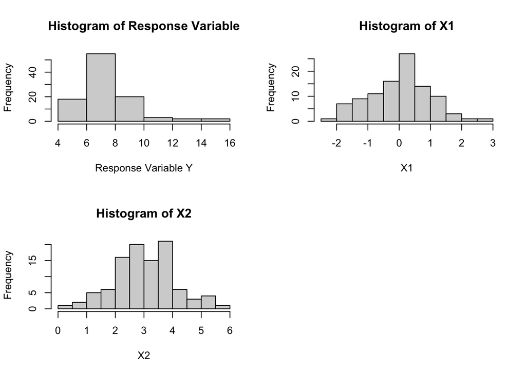

```r
par(mfrow = c(2, 2))
hist(my_data$Y, xlab='Response Variable Y', main='Histogram of Response Variable')
hist(my_data$X1, xlab='X1', main='Histogram of X1')
hist(my_data$X2, xlab='X2', main='Histogram of X2')
```

- **(c). Draw the scatter plot matrix and obtain the correlation matrix for these three variables. Briefly describe how *Y* appears to be related to *X1* and *X2*.**

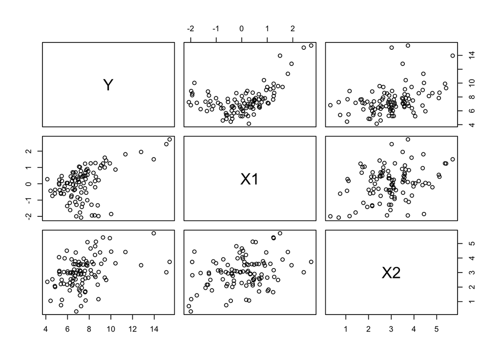

```r
# (Type your code in the space below)
pairs(my_data)
```

It looks like $Y$ is quadratically related to $X1$. The relationship is less clear with $X2.$

- **(d). Fit a first-order model with *Y* as the response variable and *X1, X2* as the predictors (referred to as Model 1). How many regression coefficients are there in Model 1?**

```r
fit_1 = lm(Y ~ X1 + X2, data=my_data)
summary(fit_1)
```

```
##
## Call:
## lm(formula = Y ~ X1 + X2, data = my_data)
##
## Residuals:
##     Min      1Q  Median      3Q     Max
## -3.1897 -1.0656 -0.3424  0.3960  5.7706
##
## Coefficients:
##             Estimate Std. Error t value Pr(>|t|)
## (Intercept)   5.9269     0.5246  11.298  < 2e-16 ***
## X1            0.7874     0.1764   4.464 2.17e-05 ***
## X2            0.4994     0.1662   3.005  0.00338 **
## ---
## Signif. codes:  0 '***' 0.001 '**' 0.01 '*' 0.05 '.' 0.1 ' ' 1
##
## Residual standard error: 1.659 on 97 degrees of freedom
## Multiple R-squared:  0.3023, Adjusted R-squared:  0.288
## F-statistic: 21.02 on 2 and 97 DF,  p-value: 2.609e-08
```

*(Type your answer here):* There are 3 regression coefficients.

- **(e). Conduct model diagnostics for Model 1 and comment on how well model assumptions hold.**

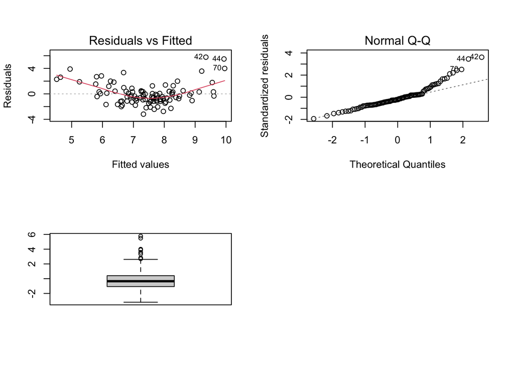

```r
par(mfrow = c(2, 2))
plot(fit_1,which=1) ##residuals vs. fitted values
plot(fit_1,which=2) ##residuals Q-Q plot
boxplot(fit_1$residuals) ## residuals boxplot
```

*(Type your answer here):* We see that the residuals versus fitted line fails to be linear, and the Normal Q-Q plot has a rather large tail, which matches the outliers seen in the boxplot. So it’s likely the linear assumptions will not hold well for this model.

- **(f). Fit a 2nd-order polynomial regression model with *Y* as the response variable and *X1, X2* as the predictors (referred to Model 2). Calculate the variance inflation factors for this model. Does there appears to be strong multicollinearity? Explain briefly.**

```r
fit_2 = lm(Y ~ X1 + X2 + I(X1^2) + X1:X2 + I(X2^2), data=my_data)
summary(fit_2)
```

```
##
## Call:
## lm(formula = Y ~ X1 + X2 + I(X1^2) + X1:X2 + I(X2^2), data = my_data)
##
## Residuals:
##      Min       1Q   Median       3Q      Max
## -2.20233 -0.60960 -0.07387  0.57877  2.31998
##
## Coefficients:
##             Estimate Std. Error t value Pr(>|t|)
## (Intercept)  5.25851    0.70035   7.508 3.39e-11 ***
## X1           0.93613    0.33911   2.761  0.00694 **
## X2           0.16454    0.46573   0.353  0.72467
## I(X1^2)      0.99757    0.07668  13.009  < 2e-16 ***
## I(X2^2)      0.06977    0.07475   0.933  0.35304
## X1:X2       -0.05632    0.11013  -0.511  0.61031
## ---
## Signif. codes:  0 '***' 0.001 '**' 0.01 '*' 0.05 '.' 0.1 ' ' 1
##
## Residual standard error: 0.9371 on 94 degrees of freedom
## Multiple R-squared:  0.7844, Adjusted R-squared:  0.7729
## F-statistic: 68.38 on 5 and 94 DF,  p-value: < 2.2e-16
```

```r
my_data['X1_squared'] <- (my_data$X1)^2
my_data['X1_X2'] <- (my_data$X1)*(my_data$X2)
my_data['X2_squared'] <- (my_data$X2)^2

correlation_matrix_including_y <- cor(my_data)
correlation_matrix <- correlation_matrix_including_y[2:6,2:6]

inverse_correlation_matrix <- solve(correlation_matrix)

VIF <- diag(inverse_correlation_matrix)
print(VIF)
```

```
##         X1         X2 X1_squared      X1_X2 X2_squared
##  12.942934  27.499045   1.251545  13.464178  27.772480
```

We see that the largest VIF factor is 27.772, which is much larger than 10, indicating that there is strong multicollinearity within our model.

- **(g). Conduct model diagnostics for Model 2. Do model assumptions appear to hold better under Model 2 compared to under Model 1? Explain briefly.**

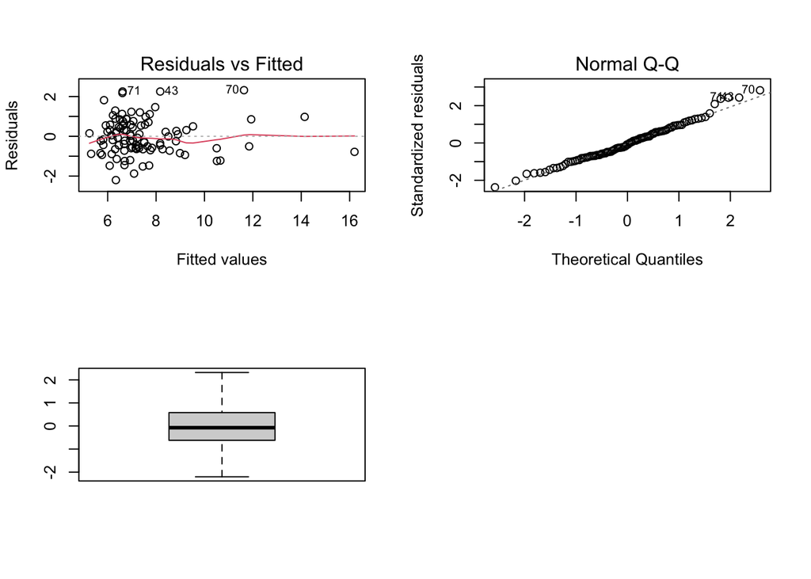

```r
par(mfrow = c(2, 2))
plot(fit_2,which=1) ##residuals vs. fitted values
plot(fit_2,which=2) ##residuals Q-Q plot
boxplot(fit_2$residuals) ## residuals boxplot
```

*(Type your answer here):*

Notice for the Normal Q-Q plot, we have a more controlled tail than that of model 1. This suggests that model 2 captures the nonlinear behavior better than the first model. We also see the residuals versus fitted lins splits the data as a line far better than model 1. So we could say that the model 2 assumptions hold better than those of model 1.

- **(h). Under Model 2, obtain the 99% confidence interval for the mean response when $X1=X2=0$.**

```r
#(Type your code in the space below)
alpha <- 1 - 0.99
hat_beta <- fit_2$coefficients
X_h = c(1, 0,0,0,0,0)
Y_h <- hat_beta %*% X_h
sqrt_MSE = sigma(fit_2)

ones <- rep(1, n)
X <- matrix(c(ones, my_data$X1, my_data$X2, my_data$X1_squared, my_data$X1_X2, my_data$X2_squared), ncol = 6)
XtXinv <- solve( (t(X) %*% X) )
s_pred_h <- sqrt_MSE*sqrt(t(X_h) %*% XtXinv %*% X_h)

p <- 6
t_val <- qt(1 - alpha / 2, df = n - p)

confidence_intercal = c(Y_h - t_val*s_pred_h, Y_h + t_val*s_pred_h)
print(confidence_intercal)
```

```
## [1] 3.417190 7.099826
```

*(Type your answer here):*

$$CI_{99 \%} = (3.417190,
7.099826)$$

- **(i). At the significance level 0.01, test whether or not all terms involving *X2* may be simultaneously dropped out of Model 2. State your conclusion.**

We develop the following hypothesis test:

- $H_0 : \beta_2 = \beta_4 = \beta_5 = 0$
- $H_A :$ not all equal to zero
- Test Statistic: $F^* = \frac{\frac{SSE(R) - SSE(F)}{df_R - df_F}}{\frac{SSE(F)}{df_F} }$
- Null distribution of $F^*$ is $F_{p - 3, n - p}(\alpha) = F_{3,94}(\alpha)$

The rule becomes is we reject $H_0$ if the following comparison is true:

```r
alpha = 0.01
SSE_F <- sum((fitted(fit_2) - my_data$Y)^2)
fit_3 = lm(Y ~ X1 + I(X1^2), data=my_data)
SSE_R <- sum((fitted(fit_3) - my_data$Y)^2)

F_stat <- ((SSE_R - SSE_F) / 3)/(SSE_F / (n - p))

F_crit <- qf(1 - alpha, 3, n-p, lower.tail = TRUE)
print(F_stat > F_crit)
```

```
## [1] TRUE
```

- **(j) Find a model that has less regression coefficients AND a larger adjusted coefficient of multiple determination compared to Model 2. Briefly explain how you reach this model.**

```r
fit_4 = lm(Y ~ X1 + I(X1^2) + X2, data=my_data)
summary(fit_4)
```

```
##
## Call:
## lm(formula = Y ~ X1 + I(X1^2) + X2, data = my_data)
##
## Residuals:
##      Min       1Q   Median       3Q      Max
## -2.22047 -0.56627 -0.08829  0.53604  2.53136
##
## Coefficients:
##             Estimate Std. Error t value Pr(>|t|)
## (Intercept)  4.67108    0.30693  15.219  < 2e-16 ***
## X1           0.76504    0.09905   7.724 1.09e-11 ***
## I(X1^2)      0.99374    0.06830  14.551  < 2e-16 ***
## X2           0.59043    0.09352   6.313 8.46e-09 ***
## ---
## Signif. codes:  0 '***' 0.001 '**' 0.01 '*' 0.05 '.' 0.1 ' ' 1
##
## Residual standard error: 0.9316 on 96 degrees of freedom
## Multiple R-squared:  0.7824, Adjusted R-squared:  0.7756
## F-statistic:   115 on 3 and 96 DF,  p-value: < 2.2e-16
```